# Chloe Sprague PCB Initial Conditions Notebook

```r
library(tidyverse)
library(googlesheets4)
library(here)
```

Filtering the “PCB concentrations organisms” Google Sheet. Removed the tabs that did not include concentration data. Some issues with different formatting between tabs, so I converted all to either character or numeric values.

```r
googlesheets4::gs4_deauth()
pcb.conc <- "1zmYEiVVxarWLrcy2x-qMKs6-mlwCrC7P3saNnv6EPlQ"
tabs <- sheet_names(pcb.conc)
tabs <- setdiff(tabs, c("metadata", "ref_list", "general_locs", "locs_WSDH_2006", "atlantis_groups", "units_conversion"))
clean_sheet <- function(tab) {
  df <- read_sheet(pcb.conc, sheet = tab)
  for (col in names(df)) {
    if (is.list(df[[col]])) {
      df[[col]] <- sapply(df[[col]], function(x) {
        if (length(x) == 0) NA else as.character(x[1])})}}
  numeric_cols <- c(
    "concentration",
    "SD",
    "SE",
    "max",
    "min",
    "n",
    "year",
    "lat",
    "lon",
    "%lipids")
  df <- df %>%
  mutate(across(everything(), as.character))
df <- df %>%
  mutate(
    across(
      any_of(numeric_cols),
      ~ suppressWarnings(as.numeric(.x))))
  df <- df %>%
    mutate(citation = tab)
return(df)}
```

Compiling all studies in the “PCB concentrations organisms” Google Sheets to a master dataset csv. Filtered out the “NA” Atlantis Polygon to only include data within the study site. Renamed “%lipids” column to percent_lipid because R had issues with the % symbol.

```r
master_dataset <- map_dfr(tabs, function(tab) {
  Sys.sleep(2)
  clean_sheet(tab)})
write.csv(
  master_dataset,
  here::here("data", "master_dataset.csv"),
  row.names = FALSE)

master_dataset <- master_dataset %>%
  filter(!is.na(atlantis_polygon),
         atlantis_polygon != "NA")

master_dataset <- master_dataset %>%
  rename(percent_lipid = `%lipids`)
```

Filtering the “PCB data for congener contribution” Google Sheets. Removed the tabs that did not include congener concentration data. This data was used to estimate target congener concentrations in mixtures.

```r
mix <- "https://docs.google.com/spreadsheets/d/1w5p-vemW2PjKbVQF-aWT5vi_CtTNdqeoOUr9lpMOTQU/edit?gid=452966458#gid=452966458"
mix <- sheet_names
mix <- setdiff(mix, c("species", "species_ufws", "ufws_locations", "holbert_2024", "burd2014", "west2001_locations"))

googlesheets4::gs4_deauth()
mixtures <- map_dfr(mix, function(tab) {
  df <- read_sheet(mix, sheet = tab)
  df <- df %>%
    mutate(
      across(
        where(is.list),
        ~ sapply(.x, function(x) paste(x, collapse = ", "))))
  df$citation <- tab
  df})
```

Reading Aroclor data from the “PCB_data_AMPS_initial_conditions” Google Sheet. Used to estimate target congener concentrations in Aroclor data.

```r
aroclor_profile <- read_sheet(
  "https://docs.google.com/spreadsheets/d/1X0Osvfe5_27rWOBL-iajtPNSehfC4RWiP0HbO_en_BE/edit?gid=59131839#gid=59131839",
  sheet = "Aroclor_congener_profile")
```

Concentration values were represented in three different ways: total, mean, and geometric mean. 47 observations did not specify.

```r
table(master_dataset$value)
```

```
geometric mean           mean             NA          total
           482          14621             47          20105
```

List of units used in each study and sample type. Counts for how many observations use each unit.

```r
(units_by_study <- master_dataset %>%
  select(citation, units, sample) %>%
  distinct() %>%
  arrange(citation))

write.csv(
  units_by_study,
  "units_by_study.csv",
  row.names = FALSE)

(unit_summary <- master_dataset %>%
  distinct(citation, units) %>%
  count(units, sort = TRUE))
```

Graph showing frequency of each sample type across all studies. We noticed many different variations in spelling, so we standardized in the Google Sheet.

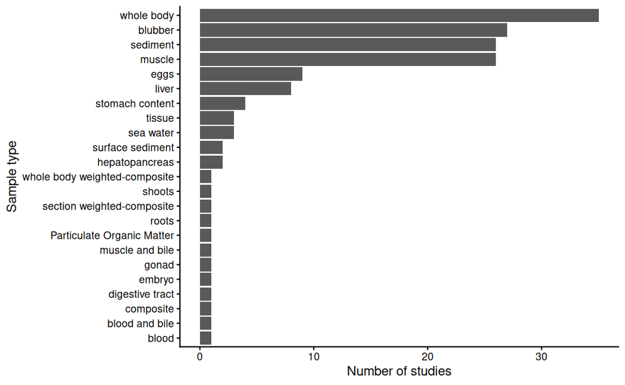

```r
master_dataset <- master_dataset %>%
  mutate(
    concentration = case_when(
      citation == "lee_2023" & PCB_congener == "11" ~ concentration / (4.23 * 0.0014 * 1.025),
      citation == "lee_2023" & PCB_congener == "28" ~ concentration / (5.40 * 0.0014 * 1.025),
      citation == "lee_2023" & PCB_congener == "52,73" ~ concentration / (5.95 * 0.0014 * 1.025),
      citation == "lee_2023" & PCB_congener == "101,89,90" ~ concentration / (6.18 * 0.0014 * 1.025),
      TRUE ~ concentration),
    units = case_when(
      citation == "lee_2023" ~ "ng/kg wet weight",
      TRUE ~ units))
```

Converting lipid weight to wet weight in a data subset. Converted each unit to mg/kg lipid weight. Some studies did not report %lipid, so we found the average %lipid in similar species and sample types in the master dataset. Made a column called percent_lipid_used to coalesce the %lipids provided and averaged through similar species (prioritizing the values provided in each study and filling in any blanks with the averaged values). Converted lipid weight to wet weight by multiplying the mg/kg lipid weight concentrations by percent_lipid_used multiplied by 100.

[output not shown]

Standardizing units in the wet weight data subset. Converted all units to mg/kg, then combined the corrected values of the lipid weight dataset with the wet weight dataset.

```r
(common_cols <- intersect(names(lipid_dataset), names(wet_dataset)))
```

```
 [1] "functional_group"   "common_name"        "sample_id"          "concentration"      "value"              "SD"
 [7] "SE"                 "max"                "min"                "units"              "n"                  "sex"
[13] "stage"              "year"               "sample"             "location"           "lat"                "lon"
[19] "atlantis_polygon"   "percent_lipid"      "no_congener"        "PCB_congener"       "congeners_analyzed" "blank_corrected"
[25] "citation"           "source"             "concentration_mgkg"
```

Converting wet weight dataset units from mg/kg to mg/m^3 using average density of the sample type.

```r
wet_dataset_new <- wet_dataset_new %>%
  mutate(
    concentration_mgm3 = case_when(
      sample %in% c("whole body", "tissue", "whole body weighted-composite", "section weighted-composite", "embryo", "muscle", "composite") ~ concentration_mgkg * 1090,
      sample == "blood" ~ concentration_mgkg * 1050,
      sample == "blood and bile" ~ concentration_mgkg * 989,
      sample == "blubber" ~ concentration_mgkg * 911,
      sample == "digestive tract" ~ concentration_mgkg * 1069,
      sample == "gonad" ~ concentration_mgkg * 1065,
      sample == "muscle and bile" ~ concentration_mgkg * 1009,
      sample %in% c("sediment", "surface sediment") ~ concentration_mgkg * 1400,
      sample == "eggs" ~ concentration_mgkg * 1075,
      sample == "liver" ~ concentration_mgkg * 1079,
      sample == "hepatopancreas" ~ concentration_mgkg * 1087,
      sample == "stomach content" ~ concentration_mgkg * 1000,
      sample %in% c("roots", "shoots") ~ concentration_mgkg * 1250,
      sample == "Particulate Organic Matter" ~ concentration_mgkg * 1230,
      sample == "sea water" ~ concentration_mgkg * 1025,
      TRUE ~ NA_real_))
```

Standardizing the dry weight data subset. Converting to mg/kg units then to mg/m^3 using average density of sample type.

| units | n |
| --- | --- |
| ug/kg dry weight | 22 |
| pg/g dry weight | 7 |
| ug/g dry weight | 2 |
| g/kg dry weight | 1 |
| mg/kg dry weight | 1 |
| ng/kg dry weight | 1 |

Wet and dry data were both converted to volumetric measurements rather than mass-based, so they can now be combined to create the new standardized master dataset.

```r
(common_cols <- intersect(names(wet_dataset_new), names(dry_dataset)))
```

```
 [1] "functional_group"   "common_name"        "sample_id"          "concentration"      "value"              "SD"
 [7] "SE"                 "max"                "min"                "units"              "n"                  "sex"
[13] "stage"              "year"               "sample"             "location"           "lat"                "lon"
[19] "atlantis_polygon"   "percent_lipid"      "no_congener"        "PCB_congener"       "congeners_analyzed" "blank_corrected"
[25] "citation"           "source"             "concentration_mgkg" "concentration_mgm3"
```

Exploratory congener figures. Coelutions were represented differently in each study (parentheses, forward slashes, plus sign). We chose to rewrite these as comma separated for consistency, similar to mixtures of multiple congeners. Exploratory graph to show the 20 most common congeners reported across all studies.

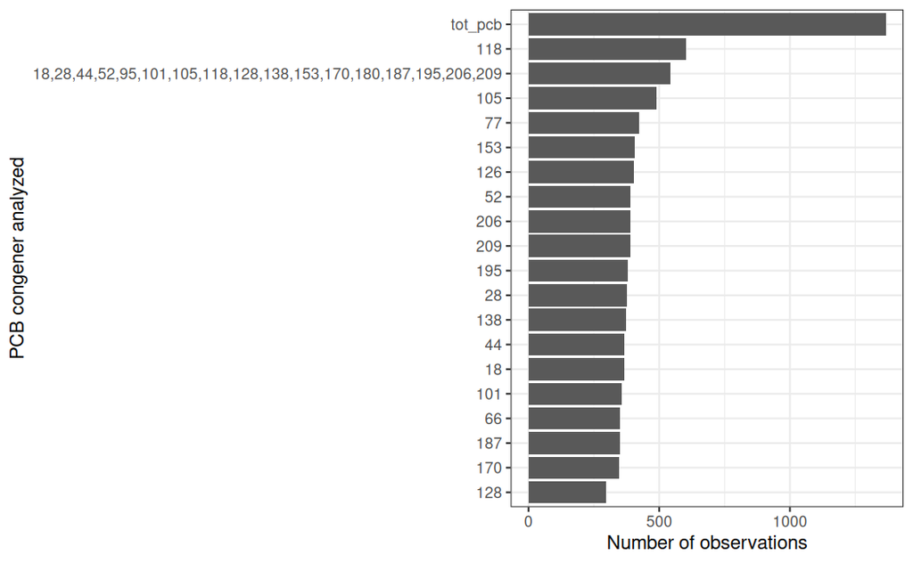

Grouping PCB_congener type into total (all 209 congeners), known mixtures (less than 209 congeners in the mixture), unknown mixtures (studies reported that multiple congeners were included in the values but didn’t specify which), and individual congener concentrations. Graph showing frequency of each type. There were originally over a thousand unknown mixture observations, but I went back to studies to find supplementary data and information and was able to narrow it down.

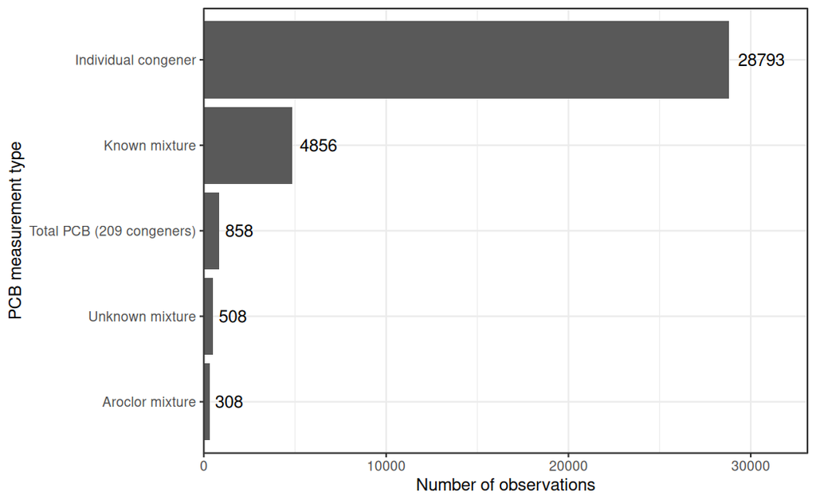

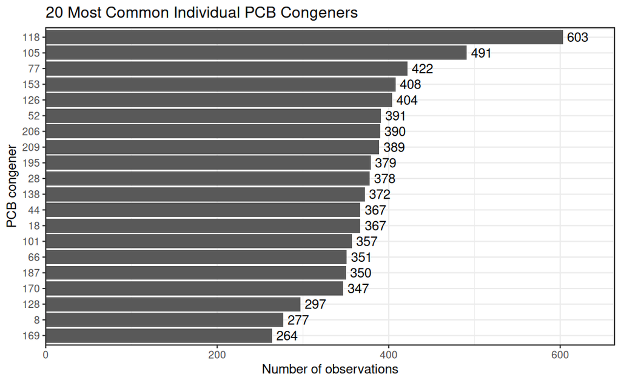

Graph showing the frequency of each Aroclor.

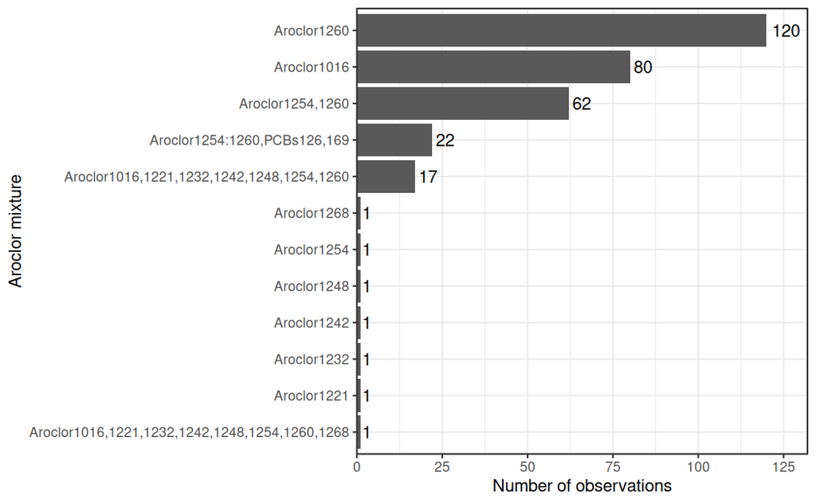

Reading the Aroclor profile sheet in the “PCB_data_AMPS_initial_conditions” Google Sheet. Issues with joining with the master sheet, so I defined the format as character.

```r
aroclor_congener <- read_sheet("https://docs.google.com/spreadsheets/d/1X0Osvfe5_27rWOBL-iajtPNSehfC4RWiP0HbO_en_BE/edit?gid=59131839#gid=59131839", sheet = "Aroclor_congener_profile")

aroclor_congener <- aroclor_congener %>%
  mutate(Aroclor = as.character(Aroclor))

aroclors <- master %>%
  left_join(
    aroclor_congener,
    by = c("PCB_congener" = "Aroclor"))
```

Recreating known mixtures to estimate concentrations of target congeners 118, 138, and 153.

Standardizing formatting. Redefining Total Pentachloro Biphenyls and Total Hexachloro Biphenyls as lists of the congeners included - only redefining these groups because they include the target congeners. Removing coelutions from being counted towards known mixtures. For simplicity, treating coelution concentrations as single congeners. Narrowing down the known mixtures to remove duplicates of mixtures per organism.

```r
unique(master_congeners$common_name)
```

```
 [1] "Northern Resident killer whale" "Southern Resident killer whale" "Transient killer whale"         "Harbor seal"
 [5] "California sea lion"            "humpback whale"                 "Steller sea lion"               "Pacific harbor seal"
 [9] "Chinook"                        "Estuary Chinook"                "Hatchery Chinook"               "Southern resident killer whale"
[13] "Brown algae"                    "Plankton"                       "Green algae"                    "Sockeye"
[17] "English sole"                   "Rock sole"                      "Staghorn sculpin"               "Graceful crab"
[21] "Shiner surf perch"              "Sand sole"                      "Sea cucumber"                   "Spotted Ratfish"
[25] "Spiny dogfish"                  "sixgill shark"                  "humpback whales"                "osprey"
[29] "Pacific sand lance"             "Pacific herring"                "Surf smelt"                     "Northern anchovy"
[33] "Chum"                           "blue heron"                     "crab"                           "mussels"
[37] "Pacific oyster"                 "Forage fish"                    "Sole"                           "Geoduck clam"
[41] "Purple seastar"                 "Whitespotted greenling"         "Small forage fish"              "Surf scoter"
[45] "Manila clam"                    "Striped seaperch"               "Pacific staghorn sculpin"       "Blue mussel"
[49] "Pile perch"                     "Dungeness crab"                 "sediment"                       "Coho"
[53] "Blackmouth salmon"              "Mussels"                        "Pink salmon"                    "Ratfish"
[57] "Butter Clam"                    "Dungeness Crab"                 "Killer whales"                  "Particulate Organic Matter"
[61] "Euphausia pacifica"             "Thysanoessa raschii"            "Thysanoessa spinifera"          "Rockfish"
[65] "Brown Rockfish"                 "Copper Rockfish"                "Quillback Rockfish"             "speckled sanddab"
```

Matching the mixture congeners to the individual congener based concentrations to recreate the mixtures. Adding the individual congeners in each mixture up to find the proportion of target congeners. Using those proportions, estimate the concentration of the target congeners in each known mixture. Including 129 in the 138 measurements because they coelute and several studies list the 138 concentration under 129 because it is a lower number.

| citation | common_name | mixtures_tab | n |
| --- | --- | --- | --- |
| WSDH_2006 | Brown Rockfish | fish | 3 |
| WSDH_2006 | Coho | fish | 5 |
| WSDH_2006 | Copper Rockfish | fish | 4 |
| WSDH_2006 | English sole | fish | 4 |
| WSDH_2006 | Quillback Rockfish | fish | 4 |
| WSDH_2006 | Rockfish | fish | 4 |
| addison_&_ross_2000 | Northern Resident killer whale | whale | 2 |
| addison_&_ross_2000 | Southern Resident killer whale | whale | 2 |
| addison_&_ross_2000 | Transient killer whale | whale | 2 |
| alava_et_al_2020 | Harbor seal | pinniped | 6 |

[output cut: 97 more lines]

Proportion of target congeners in mixures with all 209. Including coelute 129 with 138 because several tabs list the 129/138/160/163 concentration in the 129 row.

```r
mixture_proportions <- mixtures %>%
  mutate(
    IUPAC = as.character(`IUPAC Number`),
    concentration = as.numeric(Concentrations)) %>%
  filter(grepl("^[0-9]+$", IUPAC)) %>%
  mutate(IUPAC = as.integer(IUPAC)) %>%
  filter(IUPAC >= 1, IUPAC <= 209) %>%
  group_by(mixtures_tab) %>%
  summarise(
    total_congener_concentration = sum(concentration, na.rm = TRUE),
    conc118 = sum(concentration[IUPAC == 118], na.rm = TRUE),
    conc138 = sum(concentration[IUPAC %in% c("138", "129")], na.rm = TRUE),
    conc153 = sum(concentration[IUPAC == 153], na.rm = TRUE),
    .groups = "drop") %>%
  mutate(
    prop118 = conc118 / total_congener_concentration,
    prop138 = conc138 / total_congener_concentration,
    prop153 = conc153 / total_congener_concentration)
```

Using props of target congeners to estimate concentration of targets in mixtures with all 209 congeners.

Filtering dataset and grouping similar species

```r
unique(total_209$common_name)
```

```
 [1] "crab"                           "Harbor seal"                    "Chinook"                        "Rockfish"
 [5] "Pacific lingcod"                "English sole"                   "Pacific tomcod"                 "Pacific hake"
 [9] "Pacific herring"                "Pacific midshipman"             "Pacific sand lance"             "Ghost shrimp"
[13] "Spot prawn"                     "Sockeye"                        "Butter Clam"                    "zooplankton"
[17] "Benthic invertebrates"          "Southern Resident killer whale" "Transient killer whale"         "mussel"
[21] "whole benthos"                  "echinoderm"                     "horse mussel"                   "Irish Lord"
[25] "scallops"                       "Subtidal bivalves"              "Midshipman"                     "Polychaete"
[29] "Cerebratulus"                   "Heteromastus"                   "intertidal clams"               "salmon"
[33] "Great blue heron eggs"          "Blue mussel"                    "sediment"                       "horse mussels"
```

Finding target concentrations in mixtures with all congeners.

```r
target_props <- mixture_proportions %>%
  select(prop118, prop138, prop153, mixtures_tab) %>%
  distinct()

target_props_209 <- total_species %>%
  left_join(
    target_props,
    by = c("mixtures_tab"))

target_props_209 <- target_props_209 %>%
  mutate(
    conc118 = concentration_mgm3 * prop118,
    conc138 = concentration_mgm3 * prop138,
    conc153 = concentration_mgm3 * prop153)
```

Estimating targets in unknown mixtures

Filtering and sorting unknown mixtures

```r
unique(unknown$common_name)
```

```
 [1] "Southern Resident killer whale" "Transient killer whale"         "Northern Resident killer whale" "Offshore"
 [5] "Harbor seal"                    "River otters"                   "eelgrass"                       "sea cucumber"
 [9] "mussels"                        "crab"                           "English sole"                   "ratfish"
[13] "Rock sole"                      "sand sole"                      "shiner surf perch"              "staghorn sculpin"
[17] "sea water"                      "Chinook"                        "Crab"                           "Sockeye"
[21] "Coho"                           "Pacific herring"                "Fucus distichus"                "Fucus spiralis"
[25] "sediment"
```

Concentrations of targets in unknown mixtures

```r
target_props_unknown <- unknown %>%
  left_join(
    target_props,
    by = c("mixtures_tab"))

unknown_targets <- target_props_unknown %>%
  mutate(
    conc118 = concentration_mgm3 * prop118,
    conc138 = concentration_mgm3 * prop138,
    conc153 = concentration_mgm3 * prop153)
```

Estimating targets in Aroclor mixtures

Filtering and sorting

```r
unique(aroclors$common_name)
```

```
[1] "Rockfish"
[2] "English sole"
[3] "Chinook/coho salmon"
[4] "Quillback rockfish"
[5] "Pacific herring"
[6] "river otter"
[7] "Chinook"
[8] "Quillback rockfish (Sebastes maliger), brown rockfish (S.auriculatus) and copper rockfish (S. caurinus)"
[9] "sediment"
```

Estimating concentrations using 2 different methods

```r
sort(unique(aroclors$PCB_congener))
```

```
 [1] "Aroclor1016"                                    "Aroclor1016,1221,1232,1242,1248,1254,1260"
 [3] "Aroclor1016,1221,1232,1242,1248,1254,1260,1268" "Aroclor1221"
 [5] "Aroclor1232"                                    "Aroclor1242"
 [7] "Aroclor1248"                                    "Aroclor1254"
 [9] "Aroclor1254,1260"                               "Aroclor1254:1260,PCBs126,169"
[11] "Aroclor1260"                                    "Aroclor1268"
```

More concise code for assuming constant target proportions in all mixture types. **Use with caution** This includes individual congeners, known mixtures, unknown mixtures, and total congeners, so it is less accurate.

```r
unique(master$functional_group)
tot_209 <- master %>%
  filter(pcb_type == "") %>%
  select(
    citation,
    common_name,
    PCB_congener,
    no_congener,
    congeners_analyzed,
    concentration_mgm3
  ) %>%
  distinct()

similar_species <- tot_209 %>%
  mutate(
    mixtures_tab = case_when(
      functional_group %in% c("NA", "ROR", "TOR", "HUW") ~ "whale",
      functional_group %in% c("Chum", "Coho", "Chinook", "Chinook hatchery", "Hatchery Chinook", "Chinook. hatchery", "Fish", "SAL", "RAT", "ROC", "Chinook/Coho", "DOG", "HE", "ROC, MRO, DVR, MVR", "FVS", "FDF", "SMD", "FMM", "FPS", "POP", "SBL", "HE/POP/FPS", "SMD/POP/FDF", "SP", "HEP", "HEC", "PIS") ~ "fish",
      functional_group %in% c("BIV", "DUN", "BIV,BC,BMD", "PWN", "BML", "BC, BML, PWN, BFF, BIV", "BD", "BG", "BC", "GEC", "BMD", "BIV, BD, BG, BC") ~ "invert",
      functional_group %in% c("sea water", "ZM, ZL, ZS", "ZM, ZL, ZG", "ZL, ZM", "ZL", "MA", "ZM/ ZL/ ZG", "SG") ~ "water",
      functional_group %in% c("sediment", "detritus") ~ "sediment",
      functional_group %in% c("HSL", "Otter", "CSL", "PIN") ~ "pinniped",
      functional_group %in% c("SB") ~ "bird",
      TRUE ~ functional_group))

all_targets <- similar_species %>%
  left_join(
    target_props,
    by = c("mixtures_tab"))

all_targets <- all_targets %>%
  mutate(
    conc118 = concentration_mgm3 * prop118,
    conc138 = concentration_mgm3 * prop138,
    conc153 = concentration_mgm3 * prop153)
```